# Empirical Probability, Discrete Distributions, Visualizations

### 1.1.2 n=3

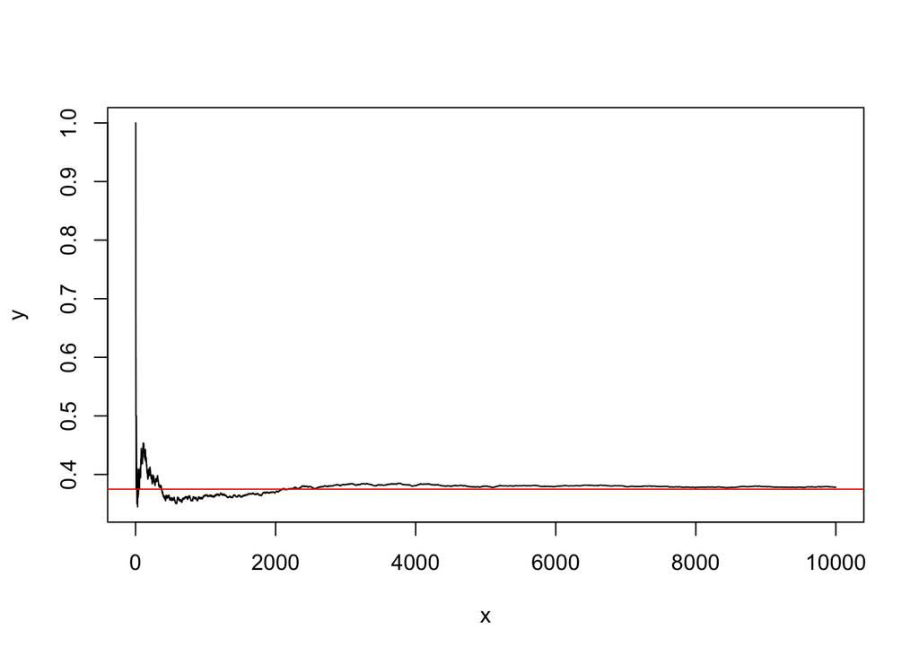

```r
sarah_ali_toss_twocoins <- function() {
  outcomes <- c(0,1)
  sarah_tosses <- sample(size = 3,
                         x = outcomes,
                         replace = TRUE,
                         prob = c(0.5, 0.5))
  ali_tosses <- sample(size = 3,
                         x = outcomes,
                         replace = TRUE,
                         prob = c(0.5, 0.5))
  return(sum(sarah_tosses) == sum(ali_tosses))
}

  x <- 1:10000
y <- c()
for(k in x){
  y <- c(y, mean(sarah_ali_exp[1:k]))
}

plot(x, y,
     type = 'l')
abline(h = 0.375,
       col = 'red')
```

### 1.1.3 General Case

Function for general case that takes parameter n for sample size.

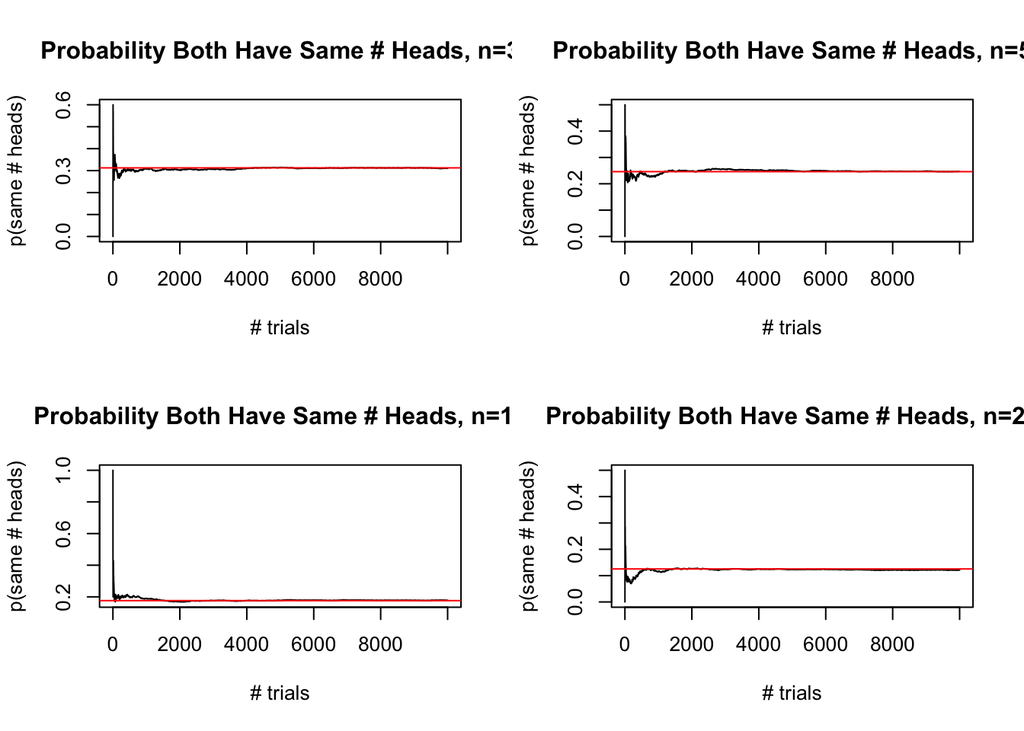

```r
# Coin toss function
# Parameters: n = number of trials
sarah_ali_toss_twocoins <- function(n) {
    outcomes <- c(0, 1)
    sarah_tosses <- sample(size = n,
                            x = outcomes,
                            replace = TRUE,
                            prob = c(0.5, 0.5))

    ali_tosses <- sample(size = n,
                            x = outcomes,
                            replace = TRUE,
                            prob = c(0.5, 0.5))
    return(sum(sarah_tosses) == sum(ali_tosses))
}

z <- list(3, 5, 10, 20)
ep <- c()
tp <- c()
j <- 1
par(mfrow=c(2,2))
for (n in z) {
    sarah_ali_exp <- replicate(10000, sarah_ali_toss_twocoins(n))
    ep <- c(ep, mean(sarah_ali_exp)) #empirical prob
    tp <- c(tp, (1 / 2)^(2 * n) * choose(2 * n, n)) #true theoretical probability
    x <- 1:10000
    y <- c()
    for (k in x) {
        y <- c(y, mean(sarah_ali_exp[1:k]))
    }

    plot(x, y,
        type = 'l', main=paste0("Probability Both Have Same # Heads, n=", n),
        ylab="p(same # heads)", xlab="# trials")
    abline(h = tp[j],
        col = 'red')

    j <- j + 1
}
```

```r
m <- matrix(c(ep, tp), ncol = 4, byrow = TRUE)
colnames(m) <- c('n=3', 'n=5', 'n=10', 'n=20')
rownames(m) <- c("Coin Toss Empirical", "Coin Toss Theoretical")
print(m)
```

```
##                          n=3       n=5      n=10      n=20
## Coin Toss Empirical   0.3103 0.2465000 0.1785000 0.1211000
## Coin Toss Theoretical 0.3125 0.2460938 0.1761971 0.1253707
```

## 1.2 Die Rolls

### 1.2.1 Fair Die

Experiment calculating sum of numbers on two independently rolled dice.

```r
# Parameters: fair = int. 0: one fair, one unfair die. Else, two fair dice
two_die <- function(fair) {
    outcomes <- c(1, 2, 3, 4, 5, 6)
    if (fair == 0) {
        p1 <- c(.1, .5, .1, .1, .1, .1)
        p2 <- c(1/6, 1/6, 1/6, 1/6, 1/6, 1/6)
        roll1 <- sample(size = 1,
                        x = outcomes,
                        replace = TRUE,
                        prob = p1)
        roll2 <- sample(size = 1,
                        x = outcomes,
                        replace = TRUE,
                        prob = p2)
        rolls <- c(roll1, roll2)
    }
    else {
        p <- c(1/6, 1/6, 1/6, 1/6, 1/6, 1/6)
        rolls <- sample(size = 2,
                        x = outcomes,
                        replace = TRUE,
                        prob = p)
    }

    return(sum(rolls))
}
```

Calling dice roll function to simulate rolling two dice 10000 times.

```r
# two_die(1) for fair die
sum_die <- replicate(10000, two_die(1))
```

Comparing empirical probabilities of getting dice sums of 2, 3, 4, …, 12 with their theoretical probabilites.

```r
sum_each <- c(sum(sum_die == 2), sum(sum_die == 3), sum(sum_die == 4), sum(sum_die == 5), sum(sum_die == 6), sum(sum_die == 7), sum(sum_die == 8), sum(sum_die == 9), sum(sum_die == 10), sum(sum_die == 11), sum(sum_die == 12))

m <- matrix(c(sum_each/10000, c(1/36, 2/36, 3/36, 4/36, 5/36, 6/36, 5/36, 4/36, 3/36, 2/36, 1/36)), ncol = 11, byrow = TRUE)
colnames(m) <- c('sum = 2', '3', '4', '5', '6', '7', '8','9', '10', '11', '12')
rownames(m) <- c("Fair Die Empirical Prob", "Fair Die Theoretical Prob")
print(m)
```

```
##                              sum = 2          3          4         5         6
## Fair Die Empirical Prob   0.02950000 0.05660000 0.08440000 0.1123000 0.1386000
## Fair Die Theoretical Prob 0.02777778 0.05555556 0.08333333 0.1111111 0.1388889
##                                   7         8         9         10         11
## Fair Die Empirical Prob   0.1601000 0.1372000 0.1115000 0.08870000 0.05590000
## Fair Die Theoretical Prob 0.1666667 0.1388889 0.1111111 0.08333333 0.05555556
##                                   12
## Fair Die Empirical Prob   0.02520000
## Fair Die Theoretical Prob 0.02777778
```

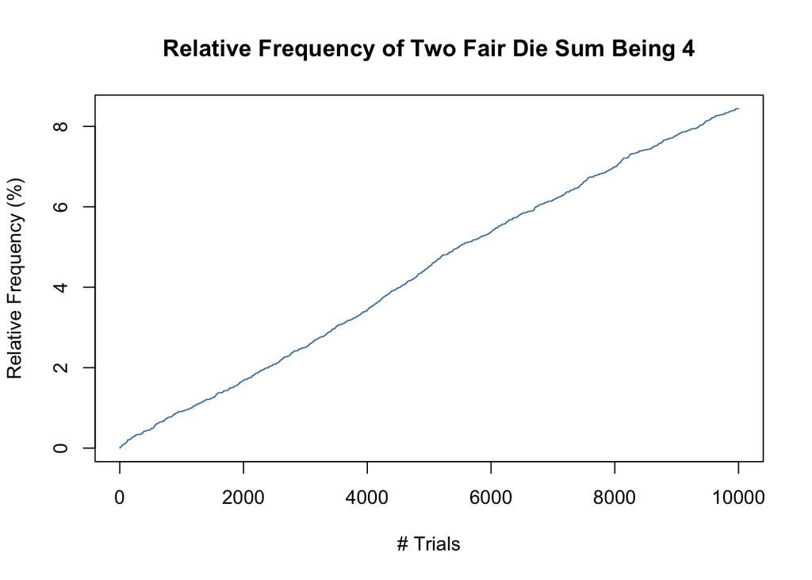

```r
plot(1:10000, cumsum(sum_die == 4)/100,
    type = "l", xlab = "# Trials", ylab = "Relative Frequency (%)",
    main = "Relative Frequency of Two Fair Die Sum Being 4", col='Steel Blue')
```

### 1.2.2 Unfair Die

Repeating the above experiment in the case when one of the die is biased to land on 2 with probability 0.5 and land with probability 0.1 of the other sides. The other die is fair.

```r
# Same function used for both fair and unfair die rolls.
two_die <- function(fair) {
    outcomes <- c(1, 2, 3, 4, 5, 6)
    if (fair == 0) {
        p1 <- c(.1, .5, .1, .1, .1, .1)
        p2 <- c(1/6, 1/6, 1/6, 1/6, 1/6, 1/6)
        roll1 <- sample(size = 1,
                        x = outcomes,
                        replace = TRUE,
                        prob = p1)
        roll2 <- sample(size = 1,
                        x = outcomes,
                        replace = TRUE,
                        prob = p2)
        rolls <- c(roll1, roll2)
    }
    else {
        p <- c(1/6, 1/6, 1/6, 1/6, 1/6, 1/6)
        rolls <- sample(size = 2,
                        x = outcomes,
                        replace = TRUE,
                        prob = p)
    }

    return(sum(rolls))
}
```

```r
# two_die(0) this time for unfair case
sum_die <- replicate(10000, two_die(0))
```

When using one unfair die, calculating empirical probabilities of getting dice sums of 2, 3, 4, …, 12 with their theoretical probabilites.

```r
sum_each <- c(sum(sum_die == 2), sum(sum_die == 3), sum(sum_die == 4), sum(sum_die == 5), sum(sum_die == 6), sum(sum_die == 7), sum(sum_die == 8), sum(sum_die == 9), sum(sum_die == 10), sum(sum_die == 11), sum(sum_die == 12))
#(.1,.5,.1,.1,.1,.1)
m <- matrix(c(sum_each/10000, c(0.1 * 1/6, 0.5 * 1/6 + 0.1 * 1/6, 0.5 * 1/6 + .2 * 1/6, 0.5 * 1/6 + .3 * 1/6, 0.5 * 1/6 + .4 * 1/6, 0.5 * 1/6 + .5 * 1/6, 0.5 * 1/6 + .4 * 1/6, .4 * 1/6, .3 * 1/6, .2 * 1/6, .1 * 1/6)), ncol = 11, byrow = TRUE)
colnames(m) <- c('sum = 2', '3', '4', '5', '6', '7', '8','9', '10', '11', '12')
rownames(m) <- c("Unfair Die Empirical Prob", "Unfair Die Theoretical Prob")
print(m)
```

```
##                                sum = 2      3         4         5      6
## Unfair Die Empirical Prob   0.01620000 0.0989 0.1125000 0.1345000 0.1504
## Unfair Die Theoretical Prob 0.01666667 0.1000 0.1166667 0.1333333 0.1500
##                                     7      8          9     10         11
## Unfair Die Empirical Prob   0.1699000 0.1534 0.06770000 0.0478 0.03140000
## Unfair Die Theoretical Prob 0.1666667 0.1500 0.06666667 0.0500 0.03333333
##                                     12
## Unfair Die Empirical Prob   0.01730000
## Unfair Die Theoretical Prob 0.01666667
```

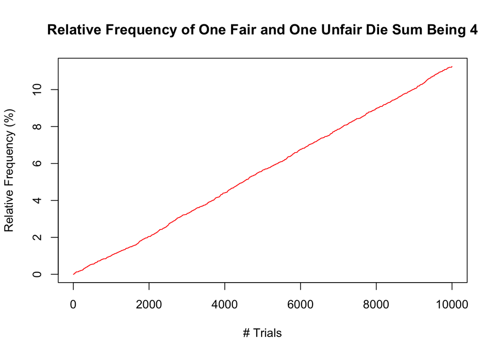

```r
plot(1:10000, cumsum(sum_die == 4)/100,
    type = "l", xlab = "# Trials", ylab = "Relative Frequency (%)",
    main = "Relative Frequency of One Fair and One Unfair Die Sum Being 4", col='Red')
```

# 2 Balls and Cells

If $n$ indistinguishable balls are placed randomly into $n$ cells, the probability that exactly one cell remains empty is calculated to be
$${n\choose 2} \frac{n!}{n^n}.$$
\

“exactly_one_cell” takes input $n$, and performs one run of this experiment.

```r
exactly_one_cell <- function(n) {
    e <- sample(1:n, n, replace = TRUE)
    return(length(unique(e)) == (n - 1))
}
```

Calculating the empirical probabilities for each of the following values of $n: 3, 6, 9, 15$, and comparing them with theoretical probabilites.

```r
n <- c(3,6,9,15)
means <- c()
theoretical_value <- c()

for (i in n) {
    balls_to_cell_exp <- replicate(100000, exactly_one_cell(i))
    means <- c(means, mean(balls_to_cell_exp))
    theoretical_value <- c(theoretical_value, choose(i, 2)*factorial(i)/(i^i))
}

m <- matrix(c(means, theoretical_value), ncol = 4, byrow = TRUE)
colnames(m) <- c('n=3', 'n=6', 'n=9', 'n=15')
rownames(m) <- c("Balls Empirical Prob", "Balls Theoretical Prob")
print(m)
```

```
##                              n=3       n=6        n=9         n=15
## Balls Empirical Prob   0.6673400 0.2302300 0.03441000 0.0002500000
## Balls Theoretical Prob 0.6666667 0.2314815 0.03371964 0.0003135595
```

# 3 Visualizing Discrete Distributions

## 3.1 Binomial distribution.

We will plot the density function for the binomial distribution Bin(n, p). Note: 1) The values for this random variable are 0, 1, 2, …, n. 2) The density plot will have a bar of height P(X=k), at the point ‘k’ on the x-axis. 3) Plot includes vertical line at the expected value of Bin(n,p).

plot_binom takes input values: n and p, and returns the density plot of Bin(n,p).

```r
plot_binom <- function(n, p) {
    x <- dbinom(0:n, size = n, p=p)
    title <- paste("Binomial Density: p = ", p)
    plot(type='h', x, ylab="relative frequency", main=title, lwd=5, col='orange')
    abline(v = n*p, col = 'red', lwd = 4)
}
```

Binomial density plots for n=40 and p: 0.05, 0.1, 0.4, 0.6, 0.9, 0.95.

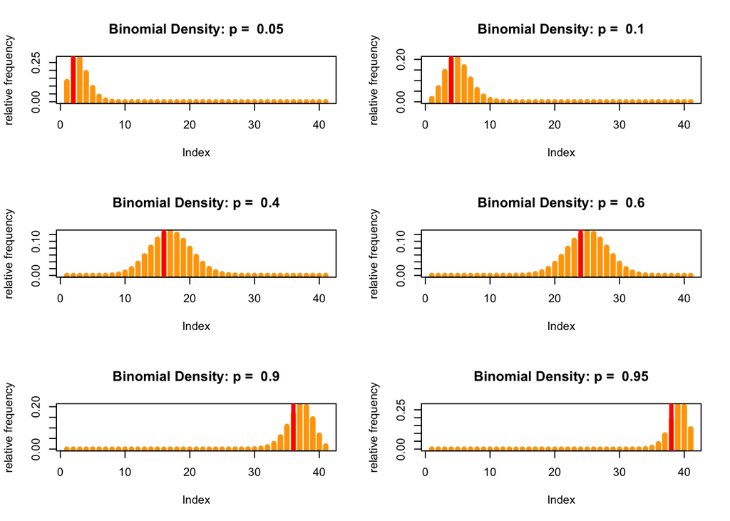

```r
par(mfrow=c(3,2))
for (i in c(.05, .1, .4, .6, .9, .95)) {
    plot_binom(40, i)
}
```

Some observations: As p approaches .5, plot appears symmetrical. Right skew when p<.5. Left skew when p>.5

## 3.2 Poisson Distribution.

We will plot the density function for the Poison distribution Pois(mu). Note: 1) The values for this random variable are: 0, 1, 2, 3, …. 2) The density plot will have a bar of height P(X=k), at the point ‘k’ on the x-axis. 3) Since most of the densities will be concentrated at lower values of k, we will fix n = 100, when drawing the density plots. 3) Plot includes a vertical line at the expected value of Pois(mu).

plot_pois takes input value mu and returns the density plot of Pois(mu).

```r
n <- 100
plot_pois <- function(mu){
  x <- 0:n
  pois <- dpois(x, lambda = mu)
  mu_X <- mu
  plot(x, pois, type = "h", lwd = 5,
       main = paste("Poisson density: mu = ", mu),
       xlab = "x", ylab = "P(X=x)")
  abline(v = mu_X, col = 'red', lwd = 4)
}
```

Poisson density plots for mu: 0.5, 1, 5, 8, 20, 50

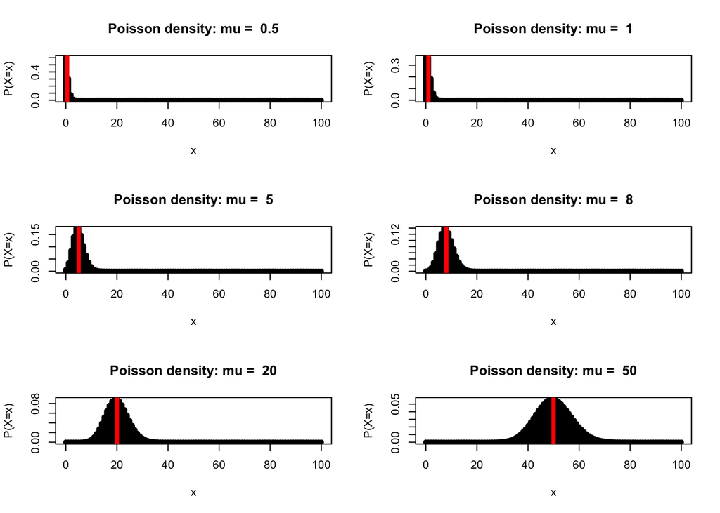

```r
par(mfrow=c(3,2))
for (i in c(.5, 1, 5, 8, 20, 50)) {
    plot_pois(i)
}
```

plot_binom(100, 0.05) and plot_pois(5) in the same frame

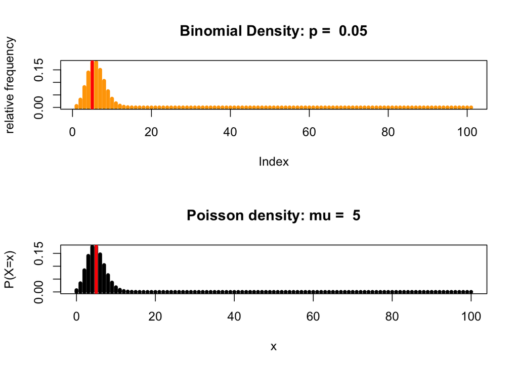

```r
par(mfrow = c(2,1))
plot_binom(100, 0.05)
plot_pois(5)
```

Observations: The density plot for poisson given lambda=5 and binomial density given p=.05 look very similar This makes sense since mu=n*p=100*.05=5. The parameters of these distributions are equal.

# 4 Visualizing Continuous Distributions

## 4.1 Normal Distibution

### 4.1.1 Fixed mean, varying standard deviation

### 4.1.2 Plotting Densities

Setting $\mu = 5$. For values of $\sigma$: $0.2, 0.4, 0.8, 1, 1.3, 1.8, 2$, plotting the densities of $N(\mu, \sigma)$.

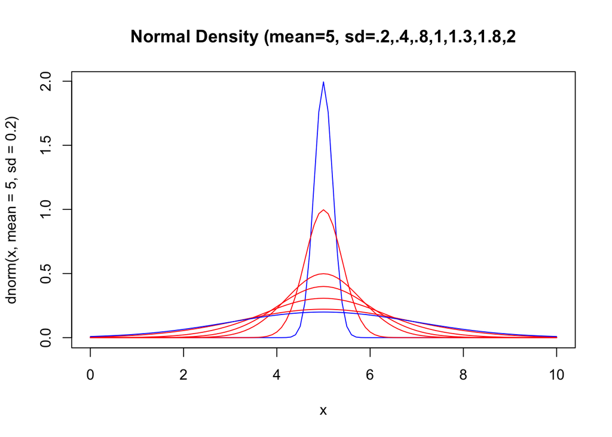

```r
nsd <- c(.4,.8,1,1.3,1.8)

par(mfrow=c(1,1))
x <- 1:10000
curve(dnorm(x, mean=5, sd=.2), from=0, to=10, main="Normal Density (mean=5, sd=.2,.4,.8,1,1.3,1.8,2", col='blue')
for (s in nsd) {
    curve(dnorm(x, mean=5, sd=s), from=0, to=10, main="Normal Density (mean=5, sd=.2,.4,.8,1,1.3,1.8,2", col='red', add=TRUE)
}
curve(dnorm(x, mean=5, sd=2), from=0, to=10, main="Normal Density (mean=5, sd=.2,.4,.8,1,1.3,1.8,2", col='blue', add=TRUE)
```

Observation: With mean constant, as standard deviation increases, the normal density curve gets flatter and wider.

#### 4.1.2.1 Plotting Cummulative Distribution Functions

Setting $\mu = 5$. Plotting the cumulative distribution function of $N(\mu, \sigma)$ for $\sigma$ = $0.2, 0.4, 0.8, 1, 1.3, 1.8, 2$.

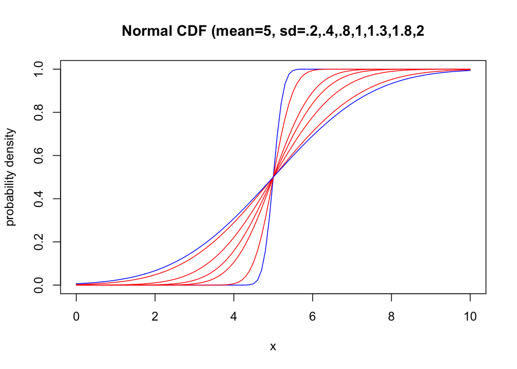

```r
nsd <- c(.4,.8,1,1.3,1.8)

par(mfrow=c(1,1))
x <- 1:10000
curve(pnorm(x, mean=5, sd=.2), from=0, to=10, ylab= "probability density", main="Normal CDF (mean=5, sd=.2,.4,.8,1,1.3,1.8,2", col='blue')
for (s in nsd) {
    curve(pnorm(x, mean=5, sd=s), from=0, to=10, main="Normal CDF (mean=5, sd=.2,.4,.8,1,1.3,1.8,2", col='red', add=TRUE)
}
curve(pnorm(x, mean=5, sd=2), from=0, to=10, main="Normal CDF (mean=5, sd=.2,.4,.8,1,1.3,1.8,2", col='blue', add=TRUE)
```

What information does the point of intersection of two cdfs give us? The cdf plots intersect at x=mean and prob density=.5. This is where the peak probability is.

### 4.1.3 Varying mean, fixed standard deviation

#### 4.1.3.1 Plotting Densities

Setting $\sigma = 0.4$. Plotting the densities of $N(\mu, \sigma)$ for values of $\mu$ given by $-1, -0.5, 0, 0.4, 0.9, 2.5, 4$.

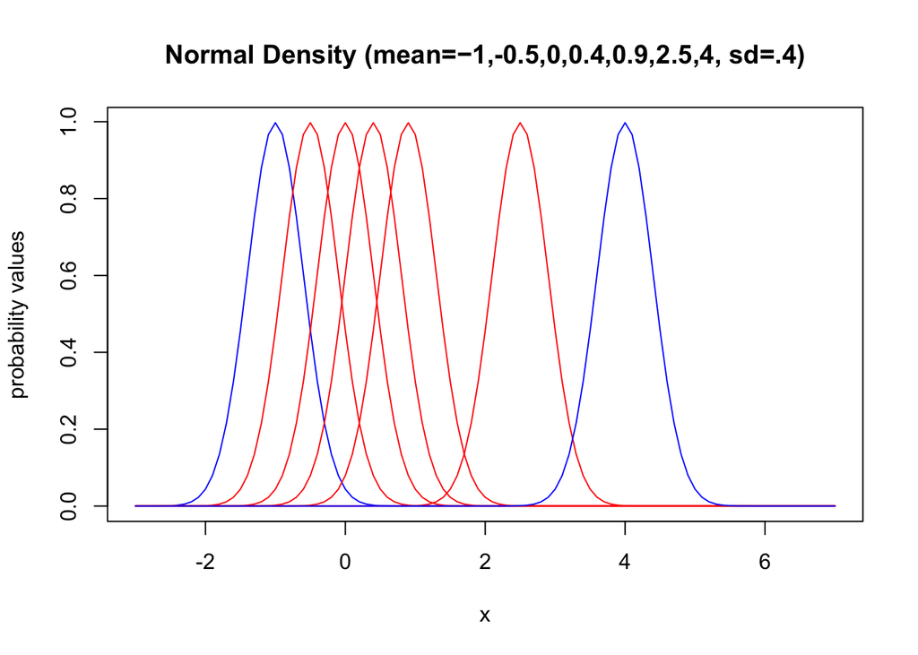

```r
means <- c(-0.5,0,0.4,0.9,2.5)

par(mfrow=c(1,1))
x <- 1:10000
curve(dnorm(x, mean=-1, sd=.4), from=-3, to=7, ylab="probability values", main="Normal Density (mean=−1,-0.5,0,0.4,0.9,2.5,4, sd=.4)", col='blue')
for (m in means) {
    curve(dnorm(x, mean=m, sd=.4), col='red', add=TRUE)
}
curve(dnorm(x, mean=4, sd=.4), col='blue', add=TRUE)
```

#### 4.1.3.2 Plotting Cummulative Distribution Functions

Plotting the cumulative distribution functions of $N(\mu, \sigma)$ for $\sigma = 0.4$ and $\mu$ = $-1, -0.5, 0, 0.4, 0.9, 2.5, 4$.

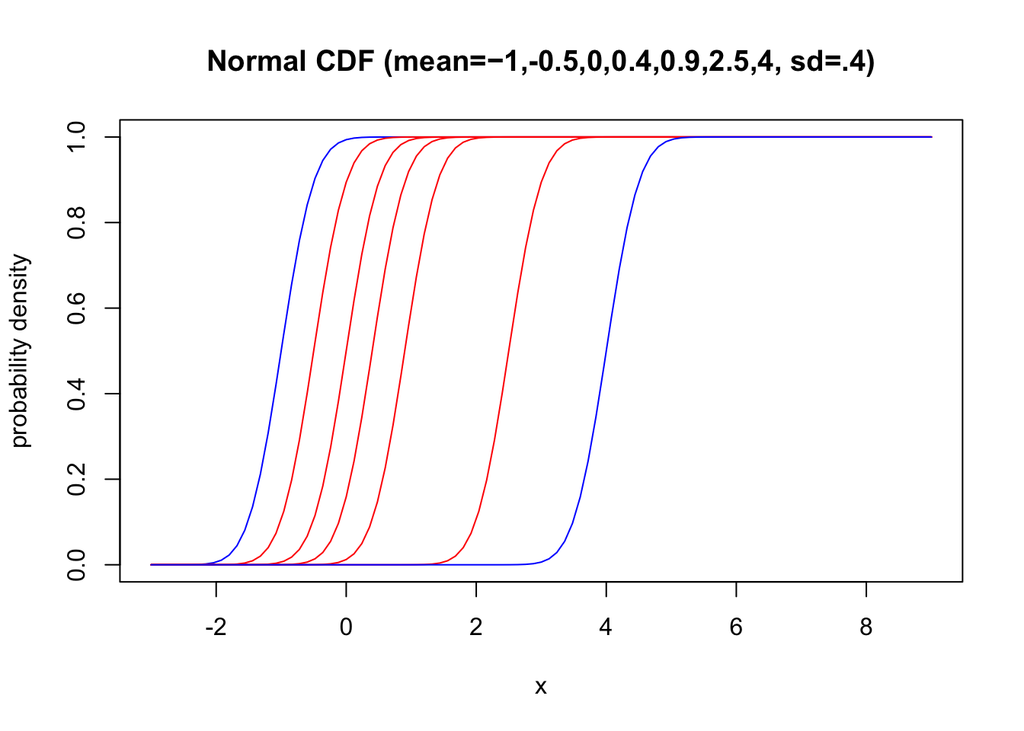

```r
means <- c(-0.5,0,0.4,0.9,2.5)

par(mfrow=c(1,1))
x <- 1:10000
curve(pnorm(x, mean=-1, sd=.4), from=-3, to=9, ylab="probability density", main="Normal CDF (mean=−1,-0.5,0,0.4,0.9,2.5,4, sd=.4)", col='blue')
for (m in means) {
    curve(pnorm(x, mean=m, sd=.4), col='red', add=TRUE)
}
curve(pnorm(x, mean=4, sd=.4), main="Normal CDF (mean=5, sd=.2,.4,.8,1,1.3,1.8,2", col='blue', add=TRUE)
```

## 4.2 Gamma Distibution

Plotting the Gamma distibution for different shapes and scales.

### 4.2.1 $\alpha =1$ , varying scales

Plotting the densities of $Gamma(\alpha, \beta)$ in a single plot for $\alpha = 1$ and $\beta$ = $0.2, 0.6, 1, 1.5, 2$.

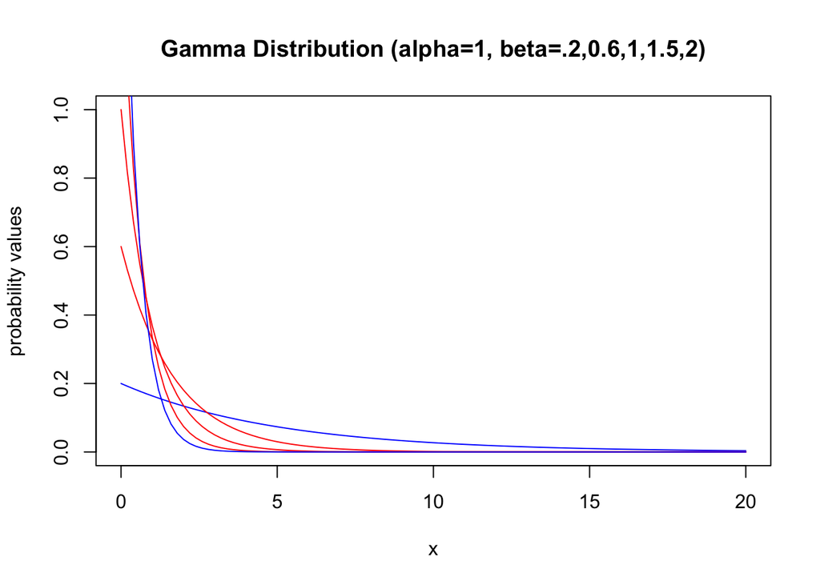

```r
betas <- c(0.6,1,1.5)

par(mfrow=c(1,1))
x <- 1:10000
curve(dgamma(x, shape=1, rate=.2), from=0, to=20, ylim=c(0,1), ylab="probability values", main="Gamma Distribution (alpha=1, beta=.2,0.6,1,1.5,2)", col='blue')
for (b in betas) {
    curve(dgamma(x, shape=1, rate=b), col='red', add=TRUE)
}
curve(dgamma(x, shape=1, rate=2), col='blue', add=TRUE)
```

### 4.2.2 $\alpha =0.6$ , varying scales

Plotting the densities of $Gamma(\alpha, \beta)$ in a single plot for $\alpha = 0.6$ and $\beta$ = $0.2, 0.6, 1, 1.5, 2$.

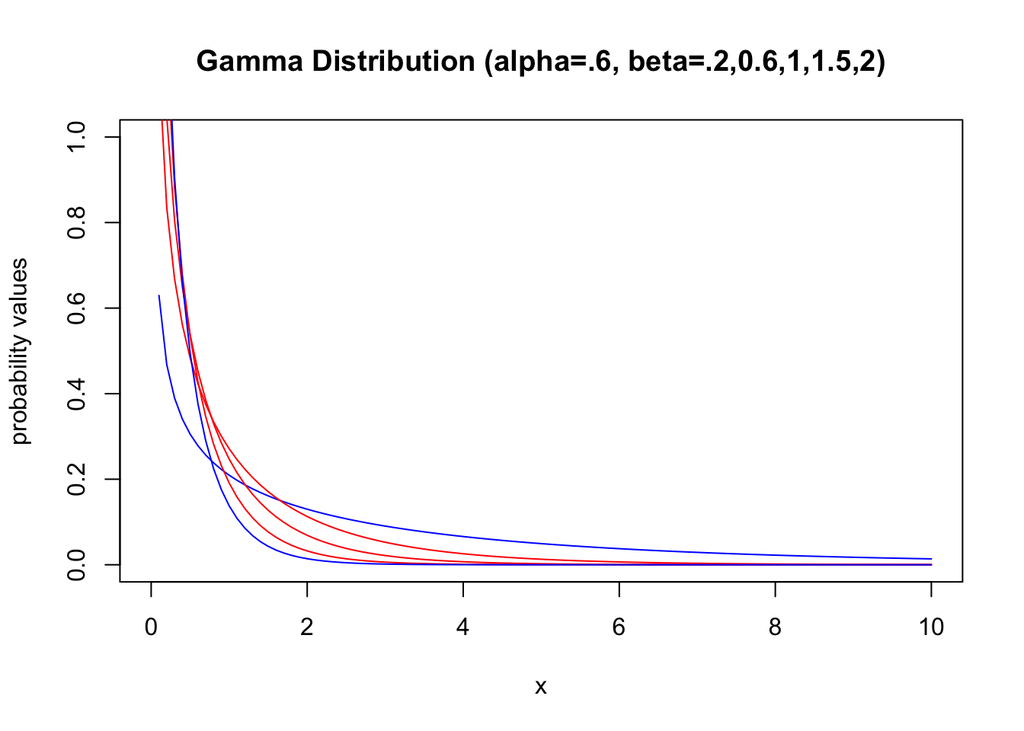

```r
betas <- c(0.6,1,1.5)

par(mfrow=c(1,1))
x <- 1:10000
curve(dgamma(x, shape=.6, rate=.2), from=0, to=10, ylim=c(0,1), ylab="probability values", main="Gamma Distribution (alpha=.6, beta=.2,0.6,1,1.5,2)", col='blue')
for (b in betas) {
    curve(dgamma(x, shape=.6, rate=b), col='red', add=TRUE)
}
curve(dgamma(x, shape=.6, rate=2), col='blue', add=TRUE)
```

### 4.2.3 $\alpha = 2$ , varying scales

Plotting the densities of $Gamma(\alpha, \beta)$ in a single plot for $\alpha = 2$ and $\beta$ = $0.2, 0.6, 1, 1.5, 2$.

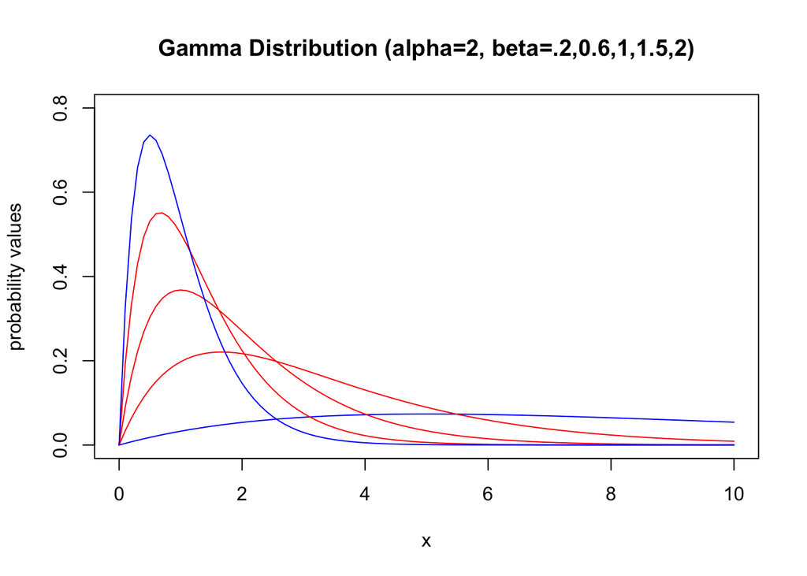

```r
betas <- c(0.6,1,1.5)

par(mfrow=c(1,1))
x <- 1:10000
curve(dgamma(x, shape=2, rate=.2), from=0, to=10, ylim=c(0,.8), ylab="probability values", main="Gamma Distribution (alpha=2, beta=.2,0.6,1,1.5,2)", col='blue')
for (b in betas) {
    curve(dgamma(x, shape=2, rate=b), col='red', add=TRUE)
}
curve(dgamma(x, shape=2, rate=2), col='blue', add=TRUE)
```

### 4.2.4 $\alpha = 5$ , varying scales

Plotting the densities of $Gamma(\alpha, \beta)$ in a single frame for $\alpha = 5$ and $\beta$ = $0.2, 0.6, 1, 1.5, 2$.

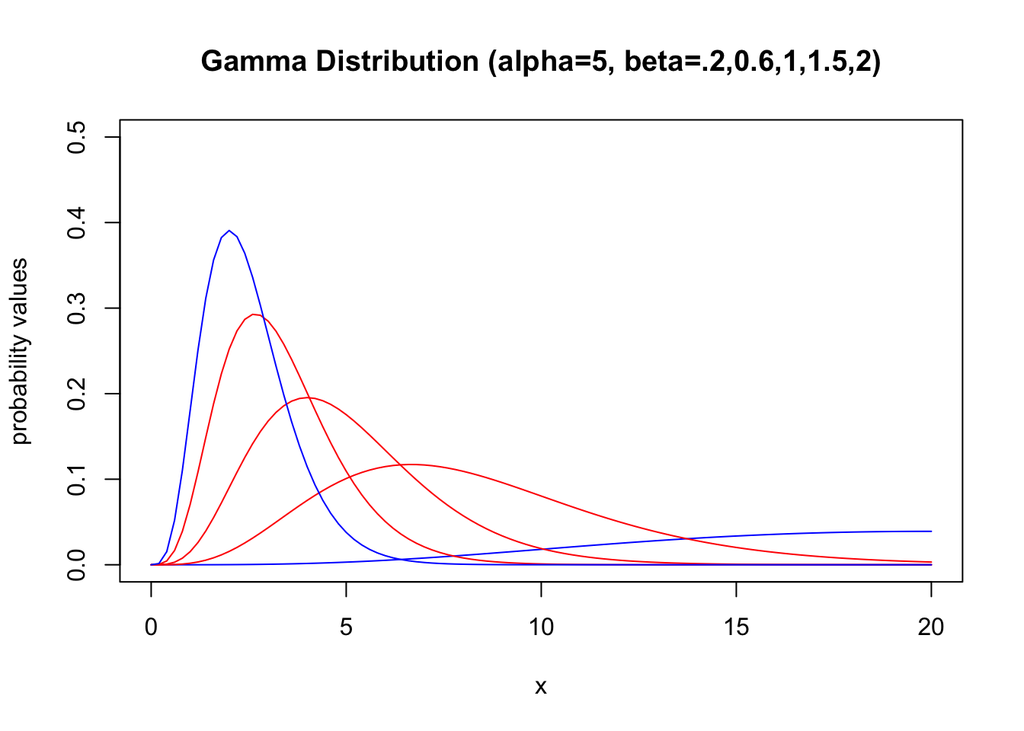

```r
betas <- c(0.6,1,1.5)

par(mfrow=c(1,1))
x <- 1:10000
curve(dgamma(x, shape=5, rate=.2), from=0, to=20, ylim=c(0,.5), ylab="probability values", main="Gamma Distribution (alpha=5, beta=.2,0.6,1,1.5,2)", col='blue')
for (b in betas) {
    curve(dgamma(x, shape=5, rate=b), col='red', add=TRUE)
}
curve(dgamma(x, shape=5, rate=2), col='blue', add=TRUE)
```

## 4.3 Beta Distribution.

Plotting the probability density function of the Beta distribution in a single plot. (1) $\alpha = 1$, $\beta = 3$ (2) $\alpha = 5$, $\beta = 1$ (3) $\alpha = 0.3$, $\beta = 0.6$ (4) $\alpha = 2$, $\beta = 2$ (5) $\alpha = 1$, $\beta = 1$

[figure not shown]

```r
par(mfrow=c(1,1))
x <- 1:10000

curve(dbeta(x, 1, 3), , lwd=1.5, from=0, to=1, ylim=c(0,3), ylab="probability values", main="Gamma Distribution(alpha=2, beta=.2,0.6,1,1.5,2)", col='#206491')
text(.5, 2.9, "alpha=1, beta=3", cex = .75, col='#206491')

curve(dbeta(x, 5, 1), col='#ff828b', lwd=1.5, add=TRUE)
text(.5, 2.8, "alpha=5, beta=1", cex = .75, col='#ff828b')

curve(dbeta(x, .3, .6), col='#cc222b', , lwd=1.5, add=TRUE)
text(.5, 2.7, "alpha=.3, beta=.6", cex = .75, col='#cc222b')

curve(dbeta(x, 2, 2), col='#cff800', lwd=1.5, add=TRUE)
text(.5, 2.6, "alpha=2, beta=2", cex = .75, col='#cff800')

curve(dbeta(x, 1, 1), col='#faa41b', lwd=1.5, add=TRUE)
text(.5, 2.5, "alpha=1, beta=1", cex = .75, col='#faa41b')
```

# 5 Simulating the Monty-Hall Problem (Optional)

Understanding the solution to the popular Monty-Hall problem through simulations of the original problem as well as some interesting variations.

## 5.1 Monty-Hall Three doors

Running a simulation to check that the probability of winning increases to 2/3 if we switch doors at step two in the regular 3-door Monty-Hall problem.

```r
monty_3doors_noswitch <- function(){
    possible <- sample(c(0, 0, 1), 3)
    choice <- sample(1:3, 1)
    return(ifelse(possible[choice]==1, 1, 0))
}

monty_3doors_switch <- function(){
    possible <- sample(c(0, 0, 1), 3)
    choice <- sample(1:3, 1)
    return(ifelse(possible[choice]!=1, 1, 0))
}
```

Storing the empirical results of winning probability to compare with theory of the original 3 door problem at the end of this exercise.

```r
mns <- replicate(10000, monty_3doors_noswitch())
ms <- replicate(10000, monty_3doors_switch())
```

## 5.2 Monty-Hall with Ten doors.

Repeating the Monty Hall experiment now with 10 doors. Recall the game is as follows: Step 1: you choose one door at random. Step 2: Monty opens 8 (out of 9 doors) that do not have the prize. Step 3: you either switch or don’t switch.

```r
monty_10doors_noswitch <- function(){
    possible <- sample(c(0, 0, 0, 0, 0, 0, 0, 0, 0, 1), 10)
    choice <- sample(1:10, 1)
    return(ifelse(possible[choice]==1, 1, 0))
}

monty_10doors_switch <- function(){
    possible <- sample(c(0, 0, 0, 0, 0, 0, 0, 0, 0, 1), 10)
    choice <- sample(1:10, 1)
    return(ifelse(possible[choice]!=1, 1, 0))
}
```

Storing the empirical results of winning probability to compare with theory for 10-door variation at the end of this exercise.

```r
m10ns <- replicate(10000, monty_10doors_noswitch())
m10s <- replicate(10000, monty_10doors_switch())
```

## 5.3 Monty-Hall 10-doors (modified).

Considering the following modified Monty-Hall game with 10 doors. Step 1: you choose one door at random. Step 2: Monty opens 7 (out of 9 doors) that do not have the prize. Step 3: you either stick with your original choice, or choose between one of the two unopened doors.

```r
monty_10doors_mod_noswitch <- function(){
    possible <- sample(c(0, 0, 0, 0, 0, 0, 0, 0, 0, 1), 10)
    choice <- sample(1:10, 1)
    return(ifelse(possible[choice]==1, 1, 0))
}

monty_10doors_mod_switch <- function(){
    possible <- sample(c(0, 0, 0, 0, 0, 0, 0, 0, 0, 1), 10)
    choice <- sample(1:10, 1)
    possible2 <- sample(c(0, 1), 2)
    choice2 <- sample(1:2, 1)
    r <- ifelse(possible2[choice2]==1, 1, 0)
    return(ifelse(possible[choice]!=1, r, 0))
}
```

Storing the empirical results of winning probability to compare with theory for the modified 10-door problem. Outputting a table comparing the empirical and theoretical results for all 3 Monty-Hall variations we have simulated.

```r
m10mns <- replicate(10000, monty_10doors_mod_noswitch())
m10ms <- replicate(10000, monty_10doors_mod_switch())

# Table with empirical vs theoretical probabilities for all 3 variations of this experiment.
m <- matrix(c(mean(mns), mean(ms), mean(m10ns), mean(m10s), mean(m10mns), mean(m10ms), 1/3, 2/3, 1/10, 9/10, 1/10, 9/20), ncol = 6, byrow = TRUE)
colnames(m) <- c('3noswitch', '3switch', '10noswitch', '10switch', 'mod10noswitch', 'mod10switch')
rownames(m) <- c("Monty Empirical Prob", "Monty Theoretical Prob")
print(m)
```

```
##                        3noswitch   3switch 10noswitch 10switch mod10noswitch
## Monty Empirical Prob   0.3384000 0.6620000     0.1015   0.9056        0.0975
## Monty Theoretical Prob 0.3333333 0.6666667     0.1000   0.9000        0.1000
##                        mod10switch
## Monty Empirical Prob        0.4565
## Monty Theoretical Prob      0.4500
```